# Data Project NHANES

Yanhang Qiu

1. Familiarize yourself with the NHANES study design and the variables in the dataset by reading the sections “About the NHANES study” and “The data set” of this document. Use the information provided to answer the following questions:
1. What are important characteristics of the NHANES study (study design, target population, study objectives, study period, …)?
   - study design: cross-sectional study
   - target population: recident non-institutionalized US population (adults and childern)
   - study objectives:to determine the prevalence of major diseases and risk factors, to design health promotion campaigns, and to establish national reference values (e.g. for height, weight, blood pressure).
   - study period: This is an ongoing study with data released in bianual cycles.
   - sampling methods: A four-stage stratified probability cluster sample.
2. What general categories (such as “demographics”, “lab results”) can the variables in the dataset be sorted into?  
   The variables in the dataset can be categorized into five main groups: demographic data, examination data, laboratory data, dietary data, and questionnaire data.

```r
data <- read.csv2("../data/NHANES1.csv",row.names = 1)
data_raw <- data

categories <- list(
  demographic_data = c("seqn","age","educ","martlst","male","ethnic","increl","age.cat","age_bin"),
  examination_data  = c("weight","height","bmi","rr_sys","rr_dia","bmi_cat"),
  dietary_data = c("rdyfood_prvmo","frzfood_prvmo","milk_month"),
  laboratory_data = c("cd","pb","hg","hdl","logHdl","hivpos")
)

categories$questionnaire_data <- setdiff(names(data), unlist(categories))
cat_df <- stack(categories)
names(cat_df) <- c("variable", "category")

summary_table <- data.frame(
  variable = names(data),
  type = sapply(data, class),
  missing = colSums(is.na(data)),
  stringsAsFactors = FALSE
)

summary_table <- merge(summary_table, cat_df, by = "variable", all.x = TRUE)

summary_table [1:5,]
```

```
##        variable      type missing           category
## 1 adlimp_prv30d   integer     746 questionnaire_data
## 2           age   integer       0   demographic_data
## 3       age.cat   integer       0   demographic_data
## 4       age_bin character       0   demographic_data
## 5       alc_lft   integer    1200 questionnaire_data
```

2. Using the subsample you have chosen, describe the US population with regards to
   1. Demographic characteristics. How can the strange age distribution be explained? To deal with this problem, recode the age variable into the following categories:18-34, 35-49, 50-64, 65-79, 80 or higher

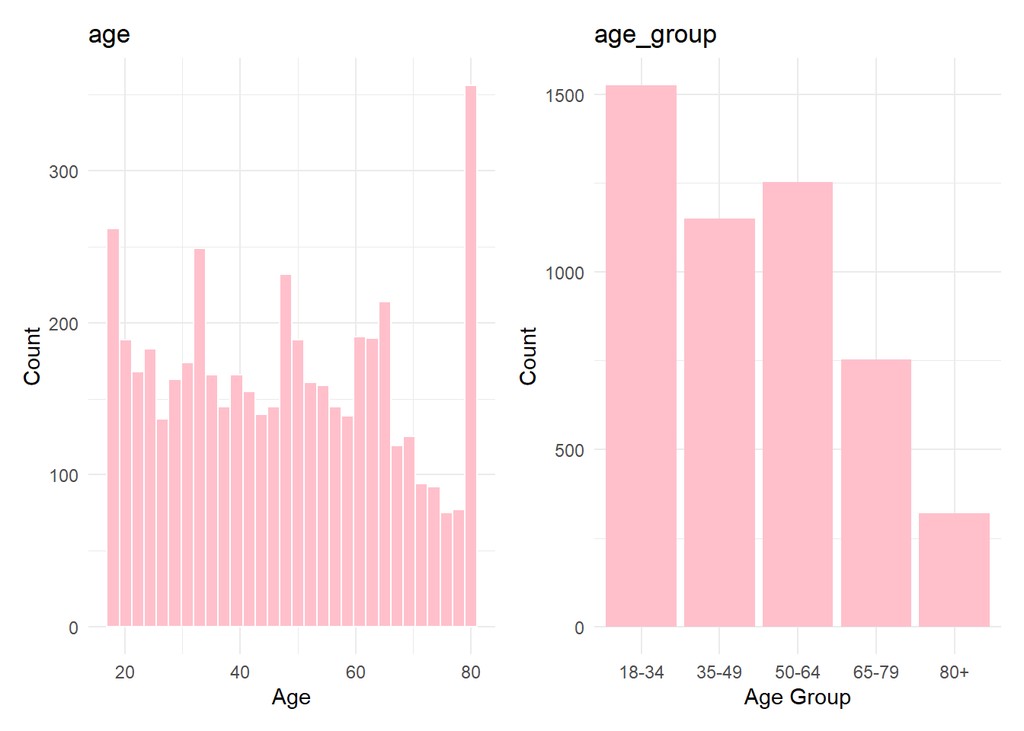

```r
library(ggplot2)

plot_age <- ggplot(data, aes(x = age)) +
  geom_histogram(fill = "pink", color = "white",bins = 30) +
  labs(title = "age",x = "Age",y = "Count") +
  theme_minimal()

library(dplyr)
data <- data %>%
  mutate(
    age_group = case_when(
      age < 18 ~ "0-17",
      age >= 18 & age < 35 ~ "18-34",
      age >= 35 & age < 50 ~ "35-49",
      age >= 50 & age < 65 ~ "50-64",
      age >= 65 & age < 80 ~ "65-79",
      age >= 80 ~ "80+"
    )
  )

plot_age_cate <-ggplot(data, aes(x=factor(age_group))) + geom_bar(fill = "pink") +
  labs(title = "age_group", x = "Age Group", y = "Count") +
  theme_minimal()


library(patchwork)
(plot_age | plot_age_cate)
```

2. When asked about Marital status, some of the participants refused to answer while some didn’t know which category they belonged. Hence they were coded differently. Take that into account and recode the variable martlst.

```r
library(dplyr)

data <- data %>%
  mutate(martlst = ifelse(is.na(martlst), 77, martlst))

data %>%
  count(martlst) %>%
  mutate(perc = round(100 * n / sum(n), 1))
```

```
##   martlst    n perc
## 1       1 2277 45.5
## 2       2  400  8.0
## 3       3  496  9.9
## 4       4  177  3.5
## 5       5 1004 20.1
## 6       6  378  7.6
## 7      77  267  5.3
## 8      99    1  0.0
```

3. Self-rated health. Looking at the results of your descriptive analysis, what do you have to consider when interpreting the results?

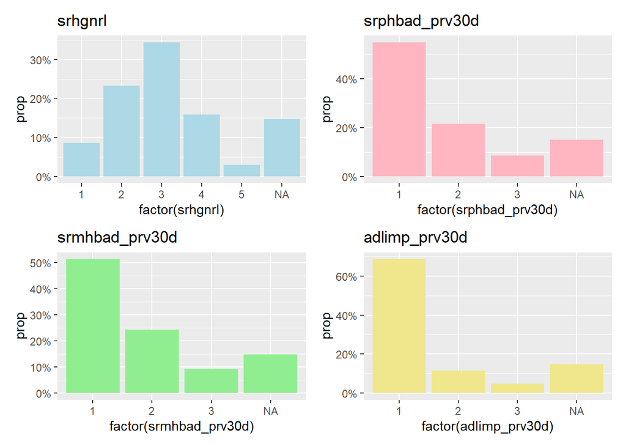

```r
library(scales)

p1 <- ggplot(data, aes(x = factor(srhgnrl), y = after_stat(prop), group = 1)) +
  geom_bar(aes(y = after_stat(prop)), fill = "lightblue") +
  scale_y_continuous(labels = percent_format()) +
  labs(title = "srhgnrl")

p2 <- ggplot(data, aes(x = factor(srphbad_prv30d), y = after_stat(prop), group = 1)) +
  geom_bar(aes(y = after_stat(prop)), fill = "lightpink") +
  scale_y_continuous(labels = percent_format()) +
  labs(title = "srphbad_prv30d")

p3 <- ggplot(data, aes(x = factor(srmhbad_prv30d), y = after_stat(prop), group = 1)) +
  geom_bar(aes(y = after_stat(prop)), fill = "lightgreen") +
  scale_y_continuous(labels = percent_format()) +
  labs(title = "srmhbad_prv30d")

p4 <- ggplot(data, aes(x = factor(adlimp_prv30d), y = after_stat(prop), group = 1)) +
  geom_bar(aes(y = after_stat(prop)), fill = "khaki") +
  scale_y_continuous(labels = percent_format()) +
  labs(title = "adlimp_prv30d")

library(patchwork)
(p1 | p2) / (p3 | p4)   # 上下排列输出
```

According to the bar charts, participants generally reported positive self-assessments of their overall, physical, and mental health during the past 30 days. However, a substantial proportion of missing values (>10%) was observed among the four self-rated health variables.

Such missingness may be systematic rather than random, potentially resulting from factors such as privacy concerns, social desirability bias, or poor physical and mental health conditions that prevent individuals from completing self-rating questions.

```r
library(dplyr)
library(tidyr)
library(ggplot2)
library(knitr)
library(broom)

self_vars <- c("srhgnrl","srphbad_prv30d","srmhbad_prv30d","adlimp_prv30d")
depr_vars <- paste0("phq", 1:9)

self_health <- data %>%
  select(seqn, hivpos, age_group, male, increl,
         all_of(self_vars), all_of(depr_vars)) %>%
  mutate(
    phq_total = rowSums(across(all_of(depr_vars)), na.rm = TRUE),
    dep_group = case_when(
      phq_total <= 4  ~ "None-minimal",
      phq_total <= 9  ~ "Mild",
      phq_total <= 14 ~ "Moderate",
      phq_total <= 19 ~ "Moderately severe",
      TRUE            ~ "Severe"
      ),

    dep_group = factor(
      dep_group,
      levels = c("None-minimal", "Mild", "Moderate", "Moderately severe", "Severe"),
      ordered = TRUE
    )
  )

self_health <- self_health %>%
  mutate(missing_self = if_else(
    rowSums(is.na(select(., all_of(self_vars)))) > 0, 1, 0
  ))


by_gender <- self_health %>%
  group_by(male) %>%
  summarise(
    n = n(),
    n_missing = sum(missing_self),
    pct_missing = round(100 * n_missing / n, 1)
  ) %>%
  mutate(group = "Gender")

by_age <- self_health %>%
  group_by(age_group) %>%
  summarise(
    n = n(),
    n_missing = sum(missing_self),
    pct_missing = round(100 * n_missing / n, 1)
  ) %>%
  mutate(group = "Age Group")

# na included
by_increl <- self_health %>%
  group_by(increl) %>%
  summarise(
    n = n(),
    n_missing = sum(missing_self),
    pct_missing = round(100 * n_missing / n, 1)
  )

by_dep <- self_health %>%
  group_by(dep_group) %>%
  summarise(
    n = n(),
    n_missing = sum(missing_self),
    pct_missing = round(100 * n_missing / n, 1)
  )


by_gender
```

```
## # A tibble: 2 × 5
##   male      n n_missing pct_missing group
##   <lgl> <int>     <dbl>       <dbl> <chr>
## 1 FALSE  2481       327        13.2 Gender
## 2 TRUE   2519       431        17.1 Gender
```

```r
by_age
```

```
## # A tibble: 5 × 5
##   age_group     n n_missing pct_missing group
##   <chr>     <int>     <dbl>       <dbl> <chr>
## 1 18-34      1525       229        15   Age Group
## 2 35-49      1149       224        19.5 Age Group
## 3 50-64      1253       157        12.5 Age Group
## 4 65-79       753        82        10.9 Age Group
## 5 80+         320        66        20.6 Age Group
```

```r
by_increl
```

```
## # A tibble: 5 × 4
##   increl     n n_missing pct_missing
##    <int> <int>     <dbl>       <dbl>
## 1      1  1220       226        18.5
## 2      2  1185       162        13.7
## 3      3  1036       119        11.5
## 4      4  1104       140        12.7
## 5     NA   455       111        24.4
```

```r
by_dep
```

```
## # A tibble: 5 × 4
##   dep_group             n n_missing pct_missing
##   <ord>             <int>     <dbl>       <dbl>
## 1 None-minimal       3984       752        18.9
## 2 Mild                640         4         0.6
## 3 Moderate            215         0         0
## 4 Moderately severe   110         1         0.9
## 5 Severe               51         1         2
```

```r
chisq.test(table(self_health$male,       self_health$missing_self, useNA = "ifany"))
```

```
##
##  Pearson's Chi-squared test with Yates' continuity correction
##
## data:  table(self_health$male, self_health$missing_self, useNA = "ifany")
## X-squared = 14.704, df = 1, p-value = 0.0001258
```

```r
chisq.test(table(self_health$age_group,  self_health$missing_self, useNA = "ifany"))
```

```
##
##  Pearson's Chi-squared test
##
## data:  table(self_health$age_group, self_health$missing_self, useNA = "ifany")
## X-squared = 41.659, df = 4, p-value = 1.963e-08
```

```r
chisq.test(table(self_health$dep_group,  self_health$missing_self, useNA = "ifany"))
```

```
##
##  Pearson's Chi-squared test
##
## data:  table(self_health$dep_group, self_health$missing_self, useNA = "ifany")
## X-squared = 210.58, df = 4, p-value < 2.2e-16
```

```r
chisq.test(table(self_health$increl,self_health$missing_self,useNA = "ifany"))
```

```
##
##  Pearson's Chi-squared test
##
## data:  table(self_health$increl, self_health$missing_self, useNA = "ifany")
## X-squared = 59.1, df = 4, p-value = 4.484e-12
```

```r
chisq.test(table(self_health$increl,self_health$missing_self))
```

```
##
##  Pearson's Chi-squared test
##
## data:  table(self_health$increl, self_health$missing_self)
## X-squared = 27.289, df = 3, p-value = 5.119e-06
```

Chi-square tests confirmed that age group, gender, depression status and income were significantly associated with missingness.Therefore, the missing data cannot be considered “Missing Completely At Random (MCAR)”.Deleting observations with missing values could introduce selection bias, and thus, appropriate methods such as multiple imputation or inclusion of missing indicators should be applied to handle these data appropriately.

3. Diabetes and ethnicity
   1. How is the diabetes status distributed in your data set? Summarize the 2 diabetes groups in a single group and recode the variable for diabetes status into two groups: non-diabetes and diabetes. Give an interval estimate for diabetes in your data set.

```r
table(data$diab_lft, useNA = "ifany")
```

```
##
##    1    2    3 <NA>
## 4090   21  581  308
```

```r
table(data$diab_lft)
```

```
##
##    1    2    3
## 4090   21  581
```

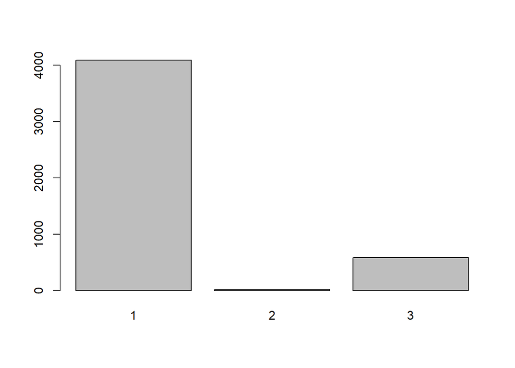

```r
barplot(table(data$diab_lft))
```

```r
data <- data %>%
  mutate(
    diabetes_status = case_when(
      diab_lft == 1 ~ "non_diabetes",
      diab_lft == 2 | diab_lft == 3 ~ "diabetes",
      TRUE ~ NA_character_
    )
  )

table(data$diabetes_status, useNA = "ifany")
```

```
##
##     diabetes non_diabetes         <NA>
##          602         4090          308
```

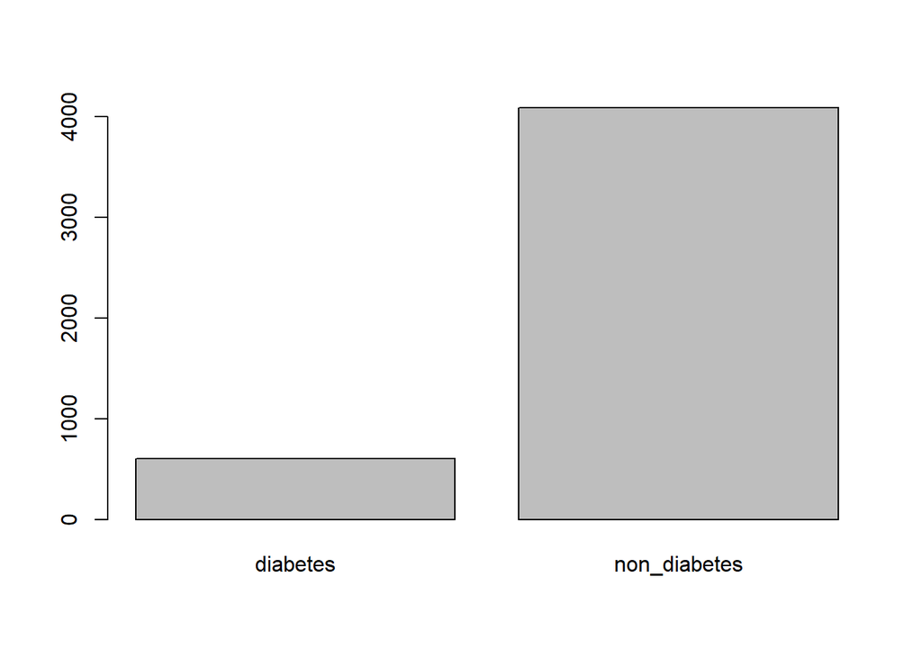

```r
barplot( table(data$diabetes_status))
```

```r
library(broom)

x <- sum(data$diabetes_status == "diabetes", na.rm = TRUE)
n <- sum(!is.na(data$diabetes_status))

result <- binom.test(x, n)
tidy(result)
```

```
## # A tibble: 1 × 8
##   estimate statistic p.value parameter conf.low conf.high method     alternative
##      <dbl>     <dbl>   <dbl>     <dbl>    <dbl>     <dbl> <chr>      <chr>
## 1    0.128       602       0      4692    0.119     0.138 Exact bin… two.sided
```

Based on our data, the estimated proportion of individuals with diabetes is about 12.8%. The 95% confidence interval ranges from 11.9% to 13.8%, meaning that if you repeated this sampling many times, 95% of such intervals would contain the true population proportion of diabetes.

```
b) Work with the recoded variable. Use an appropriate statistical test to test the relation between diabetes status and ethnicity. Inteprete the results of the test.
```